# Aula 6 - Introdução à Econometria

Autor

João Ricardo F. de Lima

Data de Publicação

20 de julho de 2026

# Modelo de Regressão Múltipla

Diferente da regressão simples, quando se tem apenas uma variável tentando explicar as mudanças em Y, no modelo de regressão múltipla é possível controlar explicitamente muitos outros fatores que, de maneira simultânea, afetam a variável dependente.

Quanto mais variáveis explicativas no modelo, mais variação de Y poderá ser explicada.

Assim, a análise de regressão múltipla pode ser usada para construir modelos melhores para prever a variável dependente.

## Estimação dos betas por MQO

Será apresentado o Modelo Clássico de Regressão Linear envolvendo k variáveis, com $k>2$ $(Y, X_1, X_2, X_3, ..., X_k)$.

Apresentado na forma matricial em (1)

$$\mathbf{Y}=\left(\begin{array}{c}
y_1\\
\vdots\\
y_n
\end{array}\right), \mathbf{ X}=\left(\begin{array}{cccc}
1 & x_{12} & \ldots & x_{1k}\\
\vdots& \vdots & \ddots & \vdots \\
1 & x_{n2} & \ldots & x_{nk}\\
\end{array}\right), \boldsymbol{\hat \beta}=\left(\begin{array}{c}
\beta_1\\
\vdots\\
\beta_k
\end{array}\right), \boldsymbol{\hat u}=\left(\begin{array}{c}
u_1\\
\vdots\\
u_n
\end{array}\right)
\tag{1}$$

Na notação matricial, reescreve-se (1) como:

$$Y=X\hat \beta+\hat u
\tag{2}$$

O modelo de regressão com $k>2$ variáveis é conhecido como **modelo de regressão múltipla**. O **modelo de regressão múltipla** é uma extensão do modelo de regressão simples. Contudo, as fórmulas matemáticas usadas para calcular $\hat \beta_1$ e $\hat \beta_2$ no modelo simples nao podem ser usadas no modelo múltiplo.

Uma forma fácil de se trabalhar com modelos de regressão múltipla é usando algebra matricial. A maior vantagem é que a solução para se estimar os coeficientes pode ser usado para simples e múltipla com qualquer número de variáveis explicativas.

Para se obter a solução do estimador de $\beta$ na forma matricial, inicialmente se escreve a função de regressão com k-variáveis:

$$Y_i=\hat \beta_1+ \hat \beta_2 X_{2i}+\hat \beta_3 X_{3i}+ \dots+\hat \beta_k X_{ki}+ \hat u_i$$

que pode ser escrito na forma matricial: com Y sendo um vetor coluna nx1; X uma matriz nxk; $\hat \beta$ um vetor coluna kx1 e o termo estocástico um vetor coluna nx1.

Os estimadores de MQO são obtidos pela minimização de:

$$\sum \hat u_i^2= \sum(Y_i- \hat \beta_1 - \hat \beta_2 X_{2i}- \dots -\hat \beta_k X_{ki})^2
\tag{3}$$

com $\sum \hat u_i^2$ sendo a soma de quadrados dos resíduos. Matricialmente, a soma do quadrados dos resíduos é dada por $\hat u' \hat u$. A partir de (2), obtem-se

$$\hat u=Y - X\hat \beta$$

Assim:

$$\sum \hat u_i^2 = \hat u'\hat u=(Y-X\hat \beta)'(Y-X\hat \beta)$$

$$=Y'Y-Y'X\hat \beta-\hat \beta' X'Y+ \hat \beta' X'X \hat \beta$$

dado que $Y'X\hat \beta$ é um escalar, é igual a sua transposta $\hat \beta'X'Y$. O último termo é a forma quadrática dos elementos de $\beta$. Então,

$$\hat u'\hat u=Y'Y-2\hat \beta'X'Y+\hat \beta' X'X \hat \beta$$

que é a função que desejamos minimizar. Para encontrar o ponto de ótimo, deve-se derivar a função e igualá-la a zero.

$$\frac {\partial \hat u'\hat u}{\partial \hat \beta}=-2X'Y+2X'X\hat \beta=0
\tag{4}$$

$$X'X\hat \beta=X'Y
\tag{5}$$

multiplicando os 2 lados por $(X'X)^{-1}$

$$(X'X)^{-1}X'X\hat \beta=(X'X)^{-1}X'Y
\tag{6}$$

tem-se

$$\hat \beta=(X'X)^{-1}X'Y
\tag{7}$$

## Demonstração no R

```r
library(wooldridge)
library(tseries)

# Carrega a base 'wage2'
data(wage2)

# Remove os valores ausentes (NAs)
sal <- na.omit(wage2)

# Dimensão da base (# linhas  # colunas)
dim(sal)
```

```
[1] 663  17
```

```r
# Descrição da base
str(sal)
```

```
'data.frame':   663 obs. of  17 variables:
 $ wage   : int  769 825 650 562 600 1154 1000 930 1318 1792 ...
 $ hours  : int  40 40 40 40 40 45 40 43 38 40 ...
 $ IQ     : int  93 108 96 74 91 111 95 132 119 118 ...
 $ KWW    : int  35 46 32 27 24 37 44 44 24 47 ...
 $ educ   : int  12 14 12 11 10 15 12 18 16 16 ...
 $ exper  : int  11 11 13 14 13 13 16 8 7 9 ...
 $ tenure : int  2 9 7 5 0 1 16 13 2 9 ...
 $ age    : int  31 33 32 34 30 36 36 38 28 34 ...
 $ married: int  1 1 1 1 0 1 1 1 1 1 ...
 $ black  : int  0 0 0 0 0 0 0 0 0 0 ...
 $ south  : int  0 0 0 0 0 0 0 0 0 0 ...
 $ urban  : int  1 1 1 1 1 0 1 0 1 1 ...
 $ sibs   : int  1 1 4 10 1 2 1 1 3 1 ...
 $ brthord: int  2 2 3 6 2 3 1 1 1 1 ...
 $ meduc  : int  8 14 12 6 8 14 12 13 10 12 ...
 $ feduc  : int  8 14 12 11 8 5 11 14 10 12 ...
 $ lwage  : num  6.65 6.72 6.48 6.33 6.4 ...
 - attr(*, "time.stamp")= chr "25 Jun 2011 23:03"
 - attr(*, "na.action")= 'omit' Named int [1:272] 2 6 8 12 13 19 20 21 31 36 ...
  ..- attr(*, "names")= chr [1:272] "2" "6" "8" "12" ...
```

O Modelo proposto para ser estimado é:

$$log(wage)= \beta_0 +\beta_1 educ + \beta_2 exper + \beta_3exper^2+ \beta_4 tenure + u$$
onde:

lwage = o logaritmo natural do salário

educ = anos de educação

exper = anos de experiência (trabalhando)

tenure = anos trabalhando com o empregador atual

```r
#Estimando a 1 Regressão Multipla Modelo Irrestrito

reg1 <- lm(log(wage) ~ educ + exper + I(exper^2) + tenure, data=sal)
summary(reg1)
```

```
Call:
lm(formula = log(wage) ~ educ + exper + I(exper^2) + tenure,
    data = sal)

Residuals:
    Min      1Q  Median      3Q     Max
-1.8515 -0.2351  0.0170  0.2491  1.3157

Coefficients:
             Estimate Std. Error t value Pr(>|t|)
(Intercept) 5.5430834  0.1419558  39.048  < 2e-16 ***
educ        0.0763886  0.0075169  10.162  < 2e-16 ***
exper       0.0079634  0.0154608   0.515  0.60667
I(exper^2)  0.0004488  0.0006674   0.673  0.50149
tenure      0.0095632  0.0030992   3.086  0.00212 **
---
Signif. codes:  0 '***' 0.001 '**' 0.01 '*' 0.05 '.' 0.1 ' ' 1

Residual standard error: 0.3791 on 658 degrees of freedom
Multiple R-squared:  0.1591,    Adjusted R-squared:  0.154
F-statistic: 31.13 on 4 and 658 DF,  p-value: < 2.2e-16
```

```r
#Testes de Normalidade
jarque.bera.test(reg1$residuals)
```

```
    Jarque Bera Test

data:  reg1$residuals
X-squared = 25.853, df = 2, p-value = 2.433e-06
```

```r
#Regressão com variáveis em log
reg2<-lm(log(wage) ~ educ + log(exper) + tenure, data=sal)
summary(reg2)
```

```
Call:
lm(formula = log(wage) ~ educ + log(exper) + tenure, data = sal)

Residuals:
     Min       1Q   Median       3Q      Max
-1.88595 -0.23687  0.02024  0.24902  1.29614

Coefficients:
            Estimate Std. Error t value Pr(>|t|)
(Intercept) 5.500423   0.145736  37.742  < 2e-16 ***
educ        0.069977   0.007174   9.754  < 2e-16 ***
log(exper)  0.116374   0.033440   3.480 0.000534 ***
tenure      0.011679   0.003009   3.881 0.000115 ***
---
Signif. codes:  0 '***' 0.001 '**' 0.01 '*' 0.05 '.' 0.1 ' ' 1

Residual standard error: 0.3811 on 659 degrees of freedom
Multiple R-squared:  0.1493,    Adjusted R-squared:  0.1454
F-statistic: 38.55 on 3 and 659 DF,  p-value: < 2.2e-16
```

```r
jarque.bera.test(reg2$residuals)
```

```
    Jarque Bera Test

data:  reg2$residuals
X-squared = 33.743, df = 2, p-value = 4.707e-08
```

```r
# Carrega a base
data("econmath")

# Descrição da base
str(econmath)
```

```
'data.frame':   856 obs. of  17 variables:
 $ age     : int  23 23 21 22 22 22 22 22 22 21 ...
 $ work    : num  15 0 25 30 25 0 20 20 28 22.5 ...
 $ study   : num  10 22.5 12 40 15 30 25 15 7 25 ...
 $ econhs  : int  0 1 0 0 1 0 1 0 0 0 ...
 $ colgpa  : num  3.49 2.1 3.09 2.68 3.75 ...
 $ hsgpa   : num  3.35 3.22 3.31 3.98 3.89 ...
 $ acteng  : int  24 23 21 31 28 25 15 28 28 18 ...
 $ actmth  : int  26 20 24 28 31 30 19 30 28 19 ...
 $ act     : int  27 24 21 31 32 28 18 32 30 17 ...
 $ mathscr : int  10 9 8 10 8 10 9 9 6 9 ...
 $ male    : int  1 1 1 0 1 1 0 1 0 0 ...
 $ calculus: int  1 0 1 1 1 1 1 1 0 1 ...
 $ attexc  : int  0 0 1 0 0 1 0 1 1 0 ...
 $ attgood : int  0 0 0 1 1 0 1 0 0 1 ...
 $ fathcoll: int  1 0 0 1 0 0 0 1 0 0 ...
 $ mothcoll: int  1 1 1 1 1 1 0 1 1 0 ...
 $ score   : num  84.4 57.4 66.4 81.2 95.9 ...
```

```r
# Estatística Descritiva
summary(econmath)
```

```
      age             work            study           econhs
 Min.   :18.00   Min.   : 0.000   Min.   : 0.00   Min.   :0.0000
 1st Qu.:19.00   1st Qu.: 0.000   1st Qu.: 8.50   1st Qu.:0.0000
 Median :19.00   Median : 8.000   Median :12.00   Median :0.0000
 Mean   :19.41   Mean   : 8.626   Mean   :13.92   Mean   :0.3703
 3rd Qu.:20.00   3rd Qu.:15.000   3rd Qu.:18.00   3rd Qu.:1.0000
 Max.   :29.00   Max.   :37.500   Max.   :50.00   Max.   :1.0000

     colgpa          hsgpa           acteng          actmth
 Min.   :0.875   Min.   :2.355   Min.   :12.00   Min.   :12.00
 1st Qu.:2.446   1st Qu.:3.110   1st Qu.:20.00   1st Qu.:20.00
 Median :2.813   Median :3.321   Median :23.00   Median :23.00
 Mean   :2.815   Mean   :3.342   Mean   :22.59   Mean   :23.21
 3rd Qu.:3.207   3rd Qu.:3.589   3rd Qu.:25.00   3rd Qu.:26.00
 Max.   :4.000   Max.   :4.260   Max.   :34.00   Max.   :36.00
                                 NAs    :42      NAs    :42
      act           mathscr            male        calculus
 Min.   :13.00   Min.   : 0.000   Min.   :0.0   Min.   :0.0000
 1st Qu.:21.00   1st Qu.: 7.000   1st Qu.:0.0   1st Qu.:0.0000
 Median :23.00   Median : 8.000   Median :0.5   Median :1.0000
 Mean   :23.12   Mean   : 7.875   Mean   :0.5   Mean   :0.6764
 3rd Qu.:25.00   3rd Qu.: 9.000   3rd Qu.:1.0   3rd Qu.:1.0000
 Max.   :33.00   Max.   :10.000   Max.   :1.0   Max.   :1.0000
 NAs    :42
     attexc          attgood          fathcoll         mothcoll
 Min.   :0.0000   Min.   :0.0000   Min.   :0.0000   Min.   :0.0000
 1st Qu.:0.0000   1st Qu.:0.0000   1st Qu.:0.0000   1st Qu.:0.0000
 Median :0.0000   Median :1.0000   Median :1.0000   Median :1.0000
 Mean   :0.2967   Mean   :0.5864   Mean   :0.5245   Mean   :0.6285
 3rd Qu.:1.0000   3rd Qu.:1.0000   3rd Qu.:1.0000   3rd Qu.:1.0000
 Max.   :1.0000   Max.   :1.0000   Max.   :1.0000   Max.   :1.0000

     score
 Min.   :19.53
 1st Qu.:64.06
 Median :74.22
 Mean   :72.60
 3rd Qu.:82.79
 Max.   :98.44
```

```r
#Estimação do modelo
reg3<-lm(score ~ study + age + actmth, data=econmath)
summary(reg3)
```

```
Call:
lm(formula = score ~ study + age + actmth, data = econmath)

Residuals:
    Min      1Q  Median      3Q     Max
-45.032  -7.602   1.660   8.904  27.893

Coefficients:
            Estimate Std. Error t value Pr(>|t|)
(Intercept) 56.38368    9.21953   6.116 1.49e-09 ***
study        0.07111    0.05472   1.299   0.1942
age         -0.94664    0.45149  -2.097   0.0363 *
actmth       1.44843    0.11330  12.784  < 2e-16 ***
---
Signif. codes:  0 '***' 0.001 '**' 0.01 '*' 0.05 '.' 0.1 ' ' 1

Residual standard error: 12.13 on 810 degrees of freedom
  (42 observations deleted due to missingness)
Multiple R-squared:  0.1725,    Adjusted R-squared:  0.1694
F-statistic: 56.27 on 3 and 810 DF,  p-value: < 2.2e-16
```

```r
#Teste de Normalidade
shapiro.test(reg3$residuals)
```

```
    Shapiro-Wilk normality test

data:  reg3$residuals
W = 0.97894, p-value = 1.919e-09
```

```r
#Estimação do modelo com variáveis transformadas
reg4<-lm(score~study+log(age)+log(actmth), data=econmath)
summary(reg4)
```

```
Call:
lm(formula = score ~ study + log(age) + log(actmth), data = econmath)

Residuals:
    Min      1Q  Median      3Q     Max
-44.877  -7.698   1.570   8.796  27.725

Coefficients:
             Estimate Std. Error t value Pr(>|t|)
(Intercept)  20.70591   28.87977   0.717   0.4736
study         0.07665    0.05462   1.403   0.1609
log(age)    -18.23167    9.28094  -1.964   0.0498 *
log(actmth)  33.50102    2.58237  12.973   <2e-16 ***
---
Signif. codes:  0 '***' 0.001 '**' 0.01 '*' 0.05 '.' 0.1 ' ' 1

Residual standard error: 12.1 on 810 degrees of freedom
  (42 observations deleted due to missingness)
Multiple R-squared:  0.1765,    Adjusted R-squared:  0.1734
F-statistic: 57.87 on 3 and 810 DF,  p-value: < 2.2e-16
```

```r
#Teste de Normalidade
shapiro.test(reg4$residuals)
```

```
    Shapiro-Wilk normality test

data:  reg4$residuals
W = 0.97933, p-value = 2.536e-09
```

```r
# Carrega a base
data("crime2")

# Descrição da base
str(crime2)
```

```
'data.frame':   92 obs. of  34 variables:
 $ pop     : num  229528 246815 814054 933177 374974 ...
 $ crimes  : num  17136 17306 75654 83960 31352 ...
 $ unem    : num  8.2 3.7 8.1 5.4 9 ...
 $ officers: int  326 321 1621 1803 633 685 245 259 504 563 ...
 $ pcinc   : int  8532 12155 7551 11363 8343 11729 7592 10802 7558 10627 ...
 $ west    : int  1 1 1 1 1 1 1 1 1 1 ...
 $ nrtheast: int  0 0 0 0 0 0 0 0 0 0 ...
 $ south   : int  0 0 0 0 0 0 0 0 0 0 ...
 $ year    : int  82 87 82 87 82 87 82 87 82 87 ...
 $ area    : num  44.6 44.6 375 375 49.8 ...
 $ d87     : int  0 1 0 1 0 1 0 1 0 1 ...
 $ popden  : num  5146 5534 2171 2488 7530 ...
 $ crmrte  : num  74.7 70.1 92.9 90 83.6 ...
 $ offarea : num  7.31 7.2 4.32 4.81 12.71 ...
```

[output cut: 21 more lines]

```r
# Estatística Descritiva
summary(crime2)
```

```
      pop              crimes            unem           officers
 Min.   :  56168   Min.   :  4124   Min.   : 2.400   Min.   : 109.0
 1st Qu.: 226182   1st Qu.: 19653   1st Qu.: 5.500   1st Qu.: 419.2
 Median : 359932   Median : 31358   Median : 6.950   Median : 717.5
 Mean   : 395461   Mean   : 39664   Mean   : 7.972   Mean   : 923.1
 3rd Qu.: 511556   3rd Qu.: 51821   3rd Qu.: 9.475   3rd Qu.:1219.8
 Max.   :1181868   Max.   :164452   Max.   :20.300   Max.   :5042.0

     pcinc            west           nrtheast          south
 Min.   : 4525   Min.   :0.0000   Min.   :0.0000   Min.   :0.0000
 1st Qu.: 7012   1st Qu.:0.0000   1st Qu.:0.0000   1st Qu.:0.0000
 Median : 8649   Median :0.0000   Median :0.0000   Median :0.0000
 Mean   : 8918   Mean   :0.3043   Mean   :0.1522   Mean   :0.3261
 3rd Qu.:10384   3rd Qu.:1.0000   3rd Qu.:0.0000   3rd Qu.:1.0000
 Max.   :14474   Max.   :1.0000   Max.   :1.0000   Max.   :1.0000

      year           area             d87          popden
 Min.   :82.0   Min.   : 13.00   Min.   :0.0   Min.   :  703.8
 1st Qu.:82.0   1st Qu.: 41.80   1st Qu.:0.0   1st Qu.: 2784.2
 Median :84.5   Median : 67.55   Median :0.5   Median : 4362.7
 Mean   :84.5   Mean   :122.73   Mean   :0.5   Mean   : 4984.5
 3rd Qu.:87.0   3rd Qu.:169.20   3rd Qu.:1.0   3rd Qu.: 6924.9
 Max.   :87.0   Max.   :604.00   Max.   :1.0   Max.   :16550.3

     crmrte          offarea          lawexpc           polpc
 Min.   : 50.02   Min.   : 1.270   Min.   : 377.5   Min.   :1.284
 1st Qu.: 77.22   1st Qu.: 5.157   1st Qu.: 746.5   1st Qu.:1.760
 Median : 92.54   Median : 8.685   Median : 877.8   Median :2.212
 Mean   :100.79   Mean   :12.175   Mean   : 958.6   Mean   :2.252
 3rd Qu.:118.92   3rd Qu.:13.362   3rd Qu.:1122.9   3rd Qu.:2.607
 Max.   :179.42   Max.   :48.382   Max.   :2262.4   Max.   :4.619

      lpop           loffic          lpcinc         llawexpc
 Min.   :10.94   Min.   :4.691   Min.   :8.417   Min.   :5.934
 1st Qu.:12.33   1st Qu.:6.038   1st Qu.:8.855   1st Qu.:6.615
 Median :12.79   Median :6.576   Median :9.065   Median :6.777
 Mean   :12.67   Mean   :6.540   Mean   :9.065   Mean   :6.817
 3rd Qu.:13.15   3rd Qu.:7.106   3rd Qu.:9.248   3rd Qu.:7.024
 Max.   :13.98   Max.   :8.526   Max.   :9.580   Max.   :7.724

```

[output cut: 17 more lines]

```
 Min.   :-0.13346   Min.   :0.08612   Min.   :-12.100   Min.   :-0.1057701
 1st Qu.:-0.02848   1st Qu.:0.18090   1st Qu.: -6.650   1st Qu.:-0.0454926
 Median : 0.01653   Median :0.29023   Median : -3.900   Median : 0.0001419
 Mean   : 0.02671   Mean   :0.31720   Mean   : -4.165   Mean   : 0.0182946
 3rd Qu.: 0.06906   3rd Qu.:0.39565   3rd Qu.: -1.575   3rd Qu.: 0.0683811
 Max.   : 0.28829   Max.   :0.97795   Max.   :  1.700   Max.   : 0.2351193
 NAs    :46         NAs    :46        NAs    :46        NAs    :46
    lcrmrt_1        ccrmrte
 Min.   :3.990   Min.   :-28.448
 1st Qu.:4.351   1st Qu.: -8.059
 Median :4.528   Median :  1.331
 Mean   :4.554   Mean   :  6.164
 3rd Qu.:4.727   3rd Qu.: 18.022
 Max.   :5.132   Max.   : 65.212
 NAs    :46      NAs    :46
```

```r
#Estimação do modelo
reg5 <- lm(crimes ~ pop + unem + officers + pcinc, data=crime2)
summary(reg5)
```

```
Call:
lm(formula = crimes ~ pop + unem + officers + pcinc, data = crime2)

Residuals:
   Min     1Q Median     3Q    Max
-27745  -6110  -1200   4139  60939

Coefficients:
              Estimate Std. Error t value Pr(>|t|)
(Intercept) -3.523e+03  1.058e+04  -0.333    0.740
pop          6.432e-02  1.079e-02   5.961 5.23e-08 ***
unem        -6.381e+01  5.519e+02  -0.116    0.908
officers     1.516e+01  3.596e+00   4.216 6.06e-05 ***
pcinc        4.779e-01  8.211e-01   0.582    0.562
---
Signif. codes:  0 '***' 0.001 '**' 0.01 '*' 0.05 '.' 0.1 ' ' 1

Residual standard error: 12600 on 87 degrees of freedom
Multiple R-squared:  0.828, Adjusted R-squared:  0.8201
F-statistic: 104.7 on 4 and 87 DF,  p-value: < 2.2e-16
```

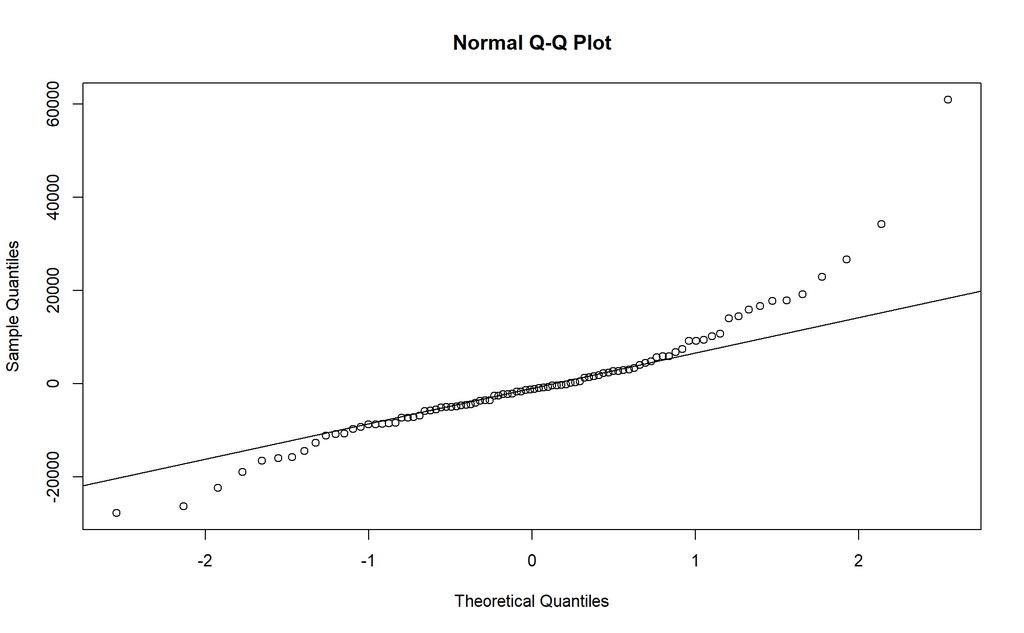

```r
#Verificação dos Resíduos
qqnorm(reg5$residuals)
qqline(reg5$residuals)
```

```r
#Teste de Normalidade
shapiro.test(reg5$residuals)
```

```
    Shapiro-Wilk normality test

data:  reg5$residuals
W = 0.89758, p-value = 2.545e-06
```

```r
#Estimação do modelo com variáveis transformadas
reg6<-lm(log(crimes)~log(pop)+log(unem)+log(officers)+log(pcinc), data=crime2)
summary(reg6)
```

```
Call:
lm(formula = log(crimes) ~ log(pop) + log(unem) + log(officers) +
    log(pcinc), data = crime2)

Residuals:
     Min       1Q   Median       3Q      Max
-0.46042 -0.16369 -0.00741  0.16572  0.62182

Coefficients:
              Estimate Std. Error t value Pr(>|t|)
(Intercept)    1.25623    1.61835   0.776    0.440
log(pop)       0.52707    0.11930   4.418 2.86e-05 ***
log(unem)     -0.08666    0.10124  -0.856    0.394
log(officers)  0.43781    0.10527   4.159 7.47e-05 ***
log(pcinc)    -0.03178    0.16067  -0.198    0.844
---
Signif. codes:  0 '***' 0.001 '**' 0.01 '*' 0.05 '.' 0.1 ' ' 1

Residual standard error: 0.2628 on 87 degrees of freedom
Multiple R-squared:  0.8801,    Adjusted R-squared:  0.8745
F-statistic: 159.6 on 4 and 87 DF,  p-value: < 2.2e-16
```

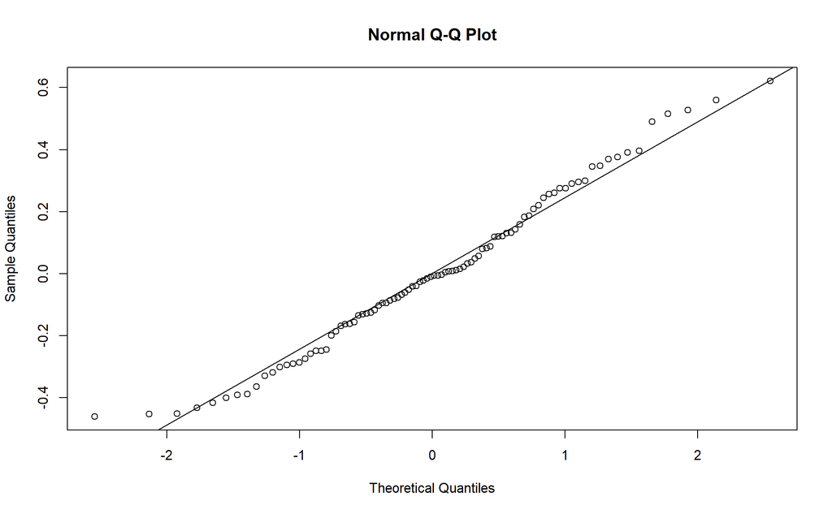

```r
#Verificação dos Resíduos
qqnorm(reg6$residuals)
qqline(reg6$residuals)
```

```r
#Teste de Normalidade
shapiro.test(reg6$residuals)
```

```
    Shapiro-Wilk normality test

data:  reg6$residuals
W = 0.98173, p-value = 0.2253
```

## Demonstração no Python - Modelos de Regressão Múltipla

```python
import wooldridge
import pandas as pd
import numpy as np
import matplotlib.pyplot as plt
import seaborn as sns
import statsmodels.formula.api as smf
import scipy.stats as stats

#Carregar dados no computador
wage2 = wooldridge.data('wage2')
econmath = wooldridge.data('econmath')
crime2 = wooldridge.data('crime2')

#Observar a estrutura dos dados
wooldridge.data('wage2', description=True)
```

```
name of dataset: wage2
no of variables: 17
no of observations: 935

+----------+-------------------------------+
| variable | label                         |
+----------+-------------------------------+
| wage     | monthly earnings              |
| hours    | average weekly hours          |
| IQ       | IQ score                      |
| KWW      | knowledge of world work score |
| educ     | years of education            |
| exper    | years of work experience      |
| tenure   | years with current employer   |
| age      | age in years                  |
| married  | =1 if married                 |
| black    | =1 if black                   |
| south    | =1 if live in south           |
| urban    | =1 if live in SMSA            |
| sibs     | number of siblings            |
| brthord  | birth order                   |
| meduc    | mother's education            |
| feduc    | father's education            |
| lwage    | natural log of wage           |
+----------+-------------------------------+

M. Blackburn and D. Neumark (1992), “Unobserved Ability, Efficiency
Wages, and Interindustry Wage Differentials,” Quarterly Journal of
Economics 107, 1421-1436. Professor Neumark kindly provided the data,
of which I used just the data for 1980.
```

```python
wage2.describe()
```

```
              wage       hours          IQ  ...       meduc       feduc       lwage
count   935.000000  935.000000  935.000000  ...  857.000000  741.000000  935.000000
mean    957.945455   43.929412  101.282353  ...   10.682614   10.217274    6.779004
std     404.360822    7.224256   15.052636  ...    2.849756    3.300700    0.421144
min     115.000000   20.000000   50.000000  ...    0.000000    0.000000    4.744932
25%     669.000000   40.000000   92.000000  ...    8.000000    8.000000    6.505783
50%     905.000000   40.000000  102.000000  ...   12.000000   10.000000    6.807935
75%    1160.000000   48.000000  112.000000  ...   12.000000   12.000000    7.056175
max    3078.000000   80.000000  145.000000  ...   18.000000   18.000000    8.032035

[8 rows x 17 columns]
```

```python
wage2.isna().sum()
```

```
wage         0
hours        0
IQ           0
KWW          0
educ         0
exper        0
tenure       0
age          0
married      0
black        0
south        0
urban        0
sibs         0
brthord     83
meduc       78
feduc      194
lwage        0
dtype: int64
```

```python
sal = wage2.dropna()

#Estimando a 1 Regressão Multipla Modelo Irrestrito
reg1 = smf.ols('np.log(wage) ~ educ + exper + I(exper**2) + tenure', data=sal)
#Output de Resultado
result1 = reg1.fit()
print(result1.summary())
```

```
                            OLS Regression Results
==============================================================================
Dep. Variable:           np.log(wage)   R-squared:                       0.159
Model:                            OLS   Adj. R-squared:                  0.154
Method:                 Least Squares   F-statistic:                     31.13
Date:                seg, 20 jul 2026   Prob (F-statistic):           9.20e-24
Time:                        09:44:01   Log-Likelihood:                -295.23
No. Observations:                 663   AIC:                             600.5
Df Residuals:                     658   BIC:                             622.9
Df Model:                           4
Covariance Type:            nonrobust
=================================================================================
                    coef    std err          t      P>|t|      [0.025      0.975]
---------------------------------------------------------------------------------
Intercept         5.5431      0.142     39.048      0.000       5.264       5.822
educ              0.0764      0.008     10.162      0.000       0.062       0.091
exper             0.0080      0.015      0.515      0.607      -0.022       0.038
I(exper ** 2)     0.0004      0.001      0.673      0.501      -0.001       0.002
tenure            0.0096      0.003      3.086      0.002       0.003       0.016
==============================================================================
Omnibus:                       15.924   Durbin-Watson:                   1.848
Prob(Omnibus):                  0.000   Jarque-Bera (JB):               25.853
Skew:                          -0.172   Prob(JB):                     2.43e-06
Kurtosis:                       3.905   Cond. No.                     1.74e+03
==============================================================================

Notes:
[1] Standard Errors assume that the covariance matrix of the errors is correctly specified.
[2] The condition number is large, 1.74e+03. This might indicate that there are
strong multicollinearity or other numerical problems.
```

Cada ano adicional de escolaridade aumenta o salário esperado em aproximadamente 7,64%, mantendo as outras variáveis constantes.

Experiência tem um termo quadrático e este deve ser interpretado conjuntamente. Neste caso, o correto é fazer:

$$\frac {\partial ln(wage)}{\partial exper} = \beta_2+ 2\beta_3 exper$$

$$\frac {\partial ln(wage)}{\partial exper} = 0,0080 + 2 (0,0004) exper$$
Isto significa que o salário aumentaria com a experiencia. Contudo, nao foram estatisticamente significativo.

Cada ano adicional no mesmo emprego aumenta o salário esperado em cerca de 0,96%, ceteris paribus.

```python
#Regressão com variáveis em log
reg2 = smf.ols('np.log(wage) ~ educ + np.log(exper) + tenure', data=sal)
#Output de Resultado
result2 = reg2.fit()
print(result2.summary())
```

```
                            OLS Regression Results
==============================================================================
Dep. Variable:           np.log(wage)   R-squared:                       0.149
Model:                            OLS   Adj. R-squared:                  0.145
Method:                 Least Squares   F-statistic:                     38.55
Date:                seg, 20 jul 2026   Prob (F-statistic):           5.82e-23
Time:                        09:44:01   Log-Likelihood:                -299.08
No. Observations:                 663   AIC:                             606.2
Df Residuals:                     659   BIC:                             624.2
Df Model:                           3
Covariance Type:            nonrobust
=================================================================================
                    coef    std err          t      P>|t|      [0.025      0.975]
---------------------------------------------------------------------------------
Intercept         5.5004      0.146     37.742      0.000       5.214       5.787
educ              0.0700      0.007      9.754      0.000       0.056       0.084
np.log(exper)     0.1164      0.033      3.480      0.001       0.051       0.182
tenure            0.0117      0.003      3.881      0.000       0.006       0.018
==============================================================================
Omnibus:                       19.371   Durbin-Watson:                   1.853
Prob(Omnibus):                  0.000   Jarque-Bera (JB):               33.743
Skew:                          -0.194   Prob(JB):                     4.71e-08
Kurtosis:                       4.035   Cond. No.                         160.
==============================================================================

Notes:
[1] Standard Errors assume that the covariance matrix of the errors is correctly specified.
```

Cada ano adicional de escolaridade aumenta o salário esperado em aproximadamente 7%, mantendo as outras variáveis constantes.

Se a experiência aumentar 1%, o salário aumenta 0,12%, aproximadamente.

Cada ano adicional no mesmo emprego aumenta o salário esperado em cerca de 1,17%, ceteris paribus.

```python
wooldridge.data('econmath', description=True)
```

```
name of dataset: econmath
no of variables: 17
no of observations: 856

+----------+----------------------------------+
| variable | label                            |
+----------+----------------------------------+
| age      | age in years                     |
| work     | hours worked per week            |
| study    | hours studying per week          |
| econhs   | =1 if economics in high school   |
| colgpa   | college GPA - beginning semester |
| hsgpa    | high school GPA                  |
| acteng   | ACT English score                |
| actmth   | ACT math score                   |
| act      | ACT composite                    |
| mathscr  | math quiz score 0-10             |
| male     | =1 if male                       |
| calculus | =1 if taken calculus course      |
| attexc   | =1 if past attndce 'excellent'   |
| attgood  | =1 if past attndce 'good'        |
| fathcoll | =1 if father has BA              |
| mothcoll | =1 if mother has BA              |
| score    | course score in percent          |
+----------+----------------------------------+

Compiled by Professor Charles Ballard, Michigan State University
Department of Economics. Professor Ballard kindly provided the data.
```

```python
econmath.describe()
```

```
              age        work       study  ...    fathcoll    mothcoll       score
count  856.000000  856.000000  856.000000  ...  856.000000  856.000000  856.000000
mean    19.406542    8.625584   13.917991  ...    0.524533    0.628505   72.599813
std      0.936913    9.228500    7.804398  ...    0.499690    0.483487   13.400678
min     18.000000    0.000000    0.000000  ...    0.000000    0.000000   19.530000
25%     19.000000    0.000000    8.500000  ...    0.000000    0.000000   64.060000
50%     19.000000    8.000000   12.000000  ...    1.000000    1.000000   74.220000
75%     20.000000   15.000000   18.000000  ...    1.000000    1.000000   82.790000
max     29.000000   37.500000   50.000000  ...    1.000000    1.000000   98.440000

[8 rows x 17 columns]
```

```python
#Estimação do modelo
reg3 = smf.ols('score ~ study + age + actmth', data=econmath)
#Output de Resultado
result3 = reg3.fit()
print(result3.summary())
```

```
                            OLS Regression Results
==============================================================================
Dep. Variable:                  score   R-squared:                       0.172
Model:                            OLS   Adj. R-squared:                  0.169
Method:                 Least Squares   F-statistic:                     56.27
Date:                seg, 20 jul 2026   Prob (F-statistic):           4.82e-33
Time:                        09:44:01   Log-Likelihood:                -3184.2
No. Observations:                 814   AIC:                             6376.
Df Residuals:                     810   BIC:                             6395.
Df Model:                           3
Covariance Type:            nonrobust
==============================================================================
                 coef    std err          t      P>|t|      [0.025      0.975]
------------------------------------------------------------------------------
Intercept     56.3837      9.220      6.116      0.000      38.287      74.481
study          0.0711      0.055      1.299      0.194      -0.036       0.179
age           -0.9466      0.451     -2.097      0.036      -1.833      -0.060
actmth         1.4484      0.113     12.784      0.000       1.226       1.671
==============================================================================
Omnibus:                       47.128   Durbin-Watson:                   2.061
Prob(Omnibus):                  0.000   Jarque-Bera (JB):               54.538
Skew:                          -0.586   Prob(JB):                     1.44e-12
Kurtosis:                       3.485   Cond. No.                         728.
==============================================================================

Notes:
[1] Standard Errors assume that the covariance matrix of the errors is correctly specified.
```

Cada hora adicional de estudo por semana aumenta a nota em 0,07 ponto percentual na escala de 0 a 100, mantendo as demais variáveis constantes. Contudo, nao foi estisticamente significativo, ou seja, não há evidência estatística de que o estudo explique o score nesta amostra.

Cada ano adicional de idade está associado a uma redução de quase 1 ponto percentual na escala de 0 a 100 no score, em média, mantendo as demais variáveis constantes.

Cada ponto adicional na variável actmth (quantidade de questões de matemática respondidas corretamente) aumenta o score em 1,45 pontos percentuais, em média.

```python
#Teste de Normalidade
shapiro_test1 = stats.shapiro(result3.resid)
print(f"Shapiro-Wilk teste estatistica: {shapiro_test1.statistic}")
```

```
Shapiro-Wilk teste estatistica: 0.978938946236081
```

```python
print(f"Shapiro-Wilk teste p-value: {shapiro_test1.pvalue}")
```

```
Shapiro-Wilk teste p-value: 1.919360952727551e-09
```

```python
#Estimação do modelo com variáveis transformadas
reg4 = smf.ols('score~study+np.log(age)+np.log(actmth)', data=econmath)
#Output de Resultado
result4 = reg4.fit()
print(result4.summary())
```

```
                            OLS Regression Results
==============================================================================
Dep. Variable:                  score   R-squared:                       0.176
Model:                            OLS   Adj. R-squared:                  0.173
Method:                 Least Squares   F-statistic:                     57.87
Date:                seg, 20 jul 2026   Prob (F-statistic):           6.72e-34
Time:                        09:44:01   Log-Likelihood:                -3182.2
No. Observations:                 814   AIC:                             6372.
Df Residuals:                     810   BIC:                             6391.
Df Model:                           3
Covariance Type:            nonrobust
==================================================================================
                     coef    std err          t      P>|t|      [0.025      0.975]
----------------------------------------------------------------------------------
Intercept         20.7059     28.880      0.717      0.474     -35.982      77.394
study              0.0767      0.055      1.403      0.161      -0.031       0.184
np.log(age)      -18.2317      9.281     -1.964      0.050     -36.449      -0.014
np.log(actmth)    33.5010      2.582     12.973      0.000      28.432      38.570
==============================================================================
Omnibus:                       46.360   Durbin-Watson:                   2.066
Prob(Omnibus):                  0.000   Jarque-Bera (JB):               53.531
Skew:                          -0.580   Prob(JB):                     2.38e-12
Kurtosis:                       3.483   Cond. No.                     1.17e+03
==============================================================================

Notes:
[1] Standard Errors assume that the covariance matrix of the errors is correctly specified.
[2] The condition number is large, 1.17e+03. This might indicate that there are
strong multicollinearity or other numerical problems.
```

Se a idade aumentar um por cento, o score (nota) vai reduzir 0,1823 pontos percentuais.

Se actmth (quantidade de questões de matemática respondidas corretamente) aumentar um por cento, o score vai aumentar 0,335 pontos percentuais.

O modelo explica 17,6% da variação nas notas. Os resíduos não seguem a distribuição Normal. Pelo teste F, de significância global, os coeficientes estimados são conjuntamente diferentes de zero.

```python
#Teste de Normalidade
shapiro_test2 = stats.shapiro(result4.resid)
print(f"Shapiro-Wilk teste estatistica: {shapiro_test2.statistic}")
```

```
Shapiro-Wilk teste estatistica: 0.9793315874110397
```

```python
print(f"Shapiro-Wilk teste p-value: {shapiro_test2.pvalue}")
```

```
Shapiro-Wilk teste p-value: 2.5360504540498245e-09
```

```python
wooldridge.data('crime2', description=True)
```

```
name of dataset: crime2
no of variables: 34
no of observations: 92

+----------+----------------------------+
| variable | label                      |
+----------+----------------------------+
| pop      | population                 |
| crimes   | total number index crimes  |
| unem     | unemployment rate          |
| officers | number police officers     |
| pcinc    | per capita income          |
| west     | =1 if city in west         |
| nrtheast | =1 if city in NE           |
| south    | =1 if city in south        |
| year     | 82 or 87                   |
| area     | land area, square miles    |
| d87      | =1 if year = 87            |
| popden   | people per sq mile         |
| crmrte   | crimes per 1000 people     |
| offarea  | officers per sq mile       |
| lawexpc  | law enforce. expend. pc, $ |
| polpc    | police per 1000 people     |
| lpop     | log(pop)                   |
| loffic   | log(officers)              |
| lpcinc   | log(pcinc)                 |
| llawexpc | log(lawexpc)               |
| lpopden  | log(popden)                |
| lcrimes  | log(crimes)                |
| larea    | log(area)                  |
| lcrmrte  | log(crmrte)                |
| clcrimes | change in lcrimes          |
| clpop    | change in lpop             |
| clcrmrte | change in lcrmrte          |
| lpolpc   | log(polpc)                 |
| clpolpc  | change in lpolpc           |
| cllawexp | change in llawexp          |
| cunem    | change in unem             |
| clpopden | change in lpopden          |
| lcrmrt_1 | lcrmrte lagged             |
| ccrmrte  | change in crmrte           |
+----------+----------------------------+

These data were collected by David Dicicco, a former MSU
undergraduate, for a final project. They came from various issues of
the County and City Data Book, and are for the years 1982 and 1985.
Unfortunately, I do not have the list of cities.
```

```python
crime2.describe()
```

```
                pop         crimes       unem  ...   clpopden   lcrmrt_1    ccrmrte
count  9.200000e+01      92.000000  92.000000  ...  46.000000  46.000000  46.000000
mean   3.954613e+05   39663.532609   7.971739  ...   0.018295   4.554047   6.163754
std    2.530911e+05   29692.101147   3.374218  ...   0.081911   0.237376  21.216339
min    5.616800e+04    4124.000000   2.400000  ...  -0.105770   3.990161 -28.448345
25%    2.261822e+05   19653.000000   5.500000  ...  -0.045493   4.350719  -8.058552
50%    3.599320e+05   31358.000000   6.950000  ...   0.000142   4.528342   1.330971
75%    5.115562e+05   51821.000000   9.475000  ...   0.068381   4.726969  18.022316
max    1.181868e+06  164452.000000  20.299999  ...   0.235119   5.131764  65.212189

[8 rows x 34 columns]
```

```python
#Estimação do modelo
reg5 = smf.ols('crimes ~ pop + unem + officers + pcinc', data=crime2)
#Output de Resultado
result5 = reg5.fit()
print(result5.summary())
```

```
                            OLS Regression Results
==============================================================================
Dep. Variable:                 crimes   R-squared:                       0.828
Model:                            OLS   Adj. R-squared:                  0.820
Method:                 Least Squares   F-statistic:                     104.7
Date:                seg, 20 jul 2026   Prob (F-statistic):           2.08e-32
Time:                        09:44:02   Log-Likelihood:                -996.55
No. Observations:                  92   AIC:                             2003.
Df Residuals:                      87   BIC:                             2016.
Df Model:                           4
Covariance Type:            nonrobust
==============================================================================
                 coef    std err          t      P>|t|      [0.025      0.975]
------------------------------------------------------------------------------
Intercept  -3523.0616   1.06e+04     -0.333      0.740   -2.46e+04    1.75e+04
pop            0.0643      0.011      5.961      0.000       0.043       0.086
unem         -63.8121    551.935     -0.116      0.908   -1160.842    1033.218
officers      15.1624      3.596      4.216      0.000       8.015      22.310
pcinc          0.4779      0.821      0.582      0.562      -1.154       2.110
==============================================================================
Omnibus:                       43.451   Durbin-Watson:                   1.175
Prob(Omnibus):                  0.000   Jarque-Bera (JB):              166.331
Skew:                           1.480   Prob(JB):                     7.62e-37
Kurtosis:                       8.885   Cond. No.                     3.78e+06
==============================================================================

Notes:
[1] Standard Errors assume that the covariance matrix of the errors is correctly specified.
[2] The condition number is large, 3.78e+06. This might indicate that there are
strong multicollinearity or other numerical problems.
```

O modelo explica 82,8% da variação no número de crimes entre as cidades/anos. Pelo teste F, o conjunto das variáveis é altamente significativo. Os resíduos não seguem a distribuição Normal.

Cada aumento de 1 pessoa na população está associado a um aumento de 0,064 crimes. A Taxa de desemprego não tem efeito significativo sobre o número de crimes neste modelo.

Cada policial adicional está associado a mais 15 crimes, em média. Isso não quer dizer que policiais “causam” crimes, mas sim que cidades com mais crimes contratam mais policiais.

A Renda per capita não mostra efeito significativo no número de crimes, quando se controla por população, desempregados e número de policiais.

```python
#Teste de Normalidade
shapiro_test3 = stats.shapiro(result5.resid)
print(f"Shapiro-Wilk teste estatistica: {shapiro_test3.statistic}")
```

```
Shapiro-Wilk teste estatistica: 0.8975835638808506
```

```python
print(f"Shapiro-Wilk teste p-value: {shapiro_test3.pvalue}")
```

```
Shapiro-Wilk teste p-value: 2.5449801464304253e-06
```

```python
# Q-Q plot
plt.figure(figsize=(12, 6))
stats.probplot(result5.resid, dist="norm", plot=plt)
```

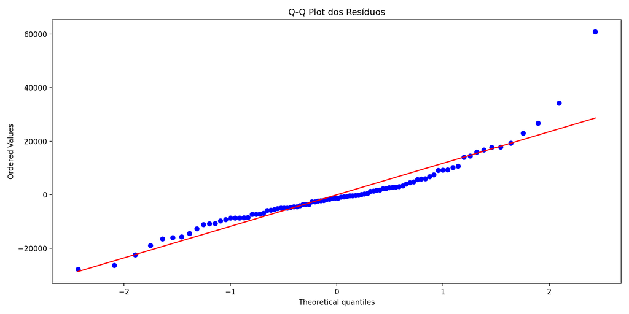

```python
plt.title('Q-Q Plot dos Resíduos')
plt.tight_layout()
plt.show();
```

```python
#Estimação do modelo com variáveis transformadas
reg6 = smf.ols('np.log(crimes)~np.log(pop)+np.log(unem)+np.log(officers)+np.log(pcinc)', data=crime2)
#Output de Resultado
result6 = reg6.fit()
print(result6.summary())
```

```
                            OLS Regression Results
==============================================================================
Dep. Variable:         np.log(crimes)   R-squared:                       0.880
Model:                            OLS   Adj. R-squared:                  0.875
Method:                 Least Squares   F-statistic:                     159.6
Date:                seg, 20 jul 2026   Prob (F-statistic):           3.39e-39
Time:                        09:44:02   Log-Likelihood:                -5.0414
No. Observations:                  92   AIC:                             20.08
Df Residuals:                      87   BIC:                             32.69
Df Model:                           4
Covariance Type:            nonrobust
====================================================================================
                       coef    std err          t      P>|t|      [0.025      0.975]
------------------------------------------------------------------------------------
Intercept            1.2562      1.618      0.776      0.440      -1.960       4.473
np.log(pop)          0.5271      0.119      4.418      0.000       0.290       0.764
np.log(unem)        -0.0867      0.101     -0.856      0.394      -0.288       0.115
np.log(officers)     0.4378      0.105      4.159      0.000       0.229       0.647
np.log(pcinc)       -0.0318      0.161     -0.198      0.844      -0.351       0.288
==============================================================================
Omnibus:                        2.040   Durbin-Watson:                   1.079
Prob(Omnibus):                  0.361   Jarque-Bera (JB):                1.891
Skew:                           0.253   Prob(JB):                        0.389
Kurtosis:                       2.514   Cond. No.                     1.01e+03
==============================================================================

Notes:
[1] Standard Errors assume that the covariance matrix of the errors is correctly specified.
[2] The condition number is large, 1.01e+03. This might indicate that there are
strong multicollinearity or other numerical problems.
```

Um aumento de 1% na população leva a um aumento de 0,53% nos crimes. Se a população crescer 10%, espera-se que o número de crimes cresça aproximadamente 5,3%, controlando pelas demais variáveis. Assim, os Crimes crescem com a população, mas menos que proporcionalmente.

Se o desemprego aumentar em 1% a quantidade de crimes reduz -0,09%, mas a variável não é estatisticamente significativa.

Se a quantidade de policiais aumentar em 1%, cresce em 0,44% a quantidade de crimes reportados. Como se tem mais crimes, são necessários mais policiais.

O aumento de 1% na renda per capita reduz em -0,03% a quantidade de crimes, mas a variável não é estatisticamente significativa.

Os resíduos seguem a distribuição Normal pelo teste de Jarque Bera e Omnibus.

```python
#Teste de Normalidade
shapiro_test4 = stats.shapiro(result6.resid)
print(f"Shapiro-Wilk teste estatistica: {shapiro_test4.statistic}")
```

```
Shapiro-Wilk teste estatistica: 0.9817299320301768
```

```python
print(f"Shapiro-Wilk teste p-value: {shapiro_test4.pvalue}")
```

```
Shapiro-Wilk teste p-value: 0.2252579880641245
```

Pelo testes de Shapiro Wilk, os resíduos seguem a distribuição Normal.

```python
# Q-Q plot
plt.figure(figsize=(12, 6))
stats.probplot(result6.resid, dist="norm", plot=plt)
```

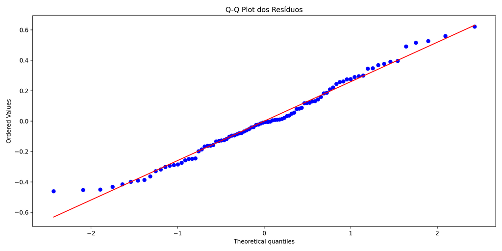

```python
plt.title('Q-Q Plot dos Resíduos')
plt.tight_layout()
plt.show();
```